# 為替レート予測検証-日本円/米ドル

アセット･マネジメント･コンサルティング株式会社 http://am-consulting.co.jp

```
## Title : 自己回帰実数和分移動平均モデル(ARFIMAモデル)による為替レート予測検証-日本円/米ドル
## Raw Data Source : OANDA Corporation - https://www.oanda.com/
## Author : アセット･マネジメント･コンサルティング株式会社 http://am-consulting.co.jp
## 作成日 : 2016-08-22 00:47:23
```

### Pattern 1 : 2016-07-12 - 2016-08-10 の為替レートによる予測検証

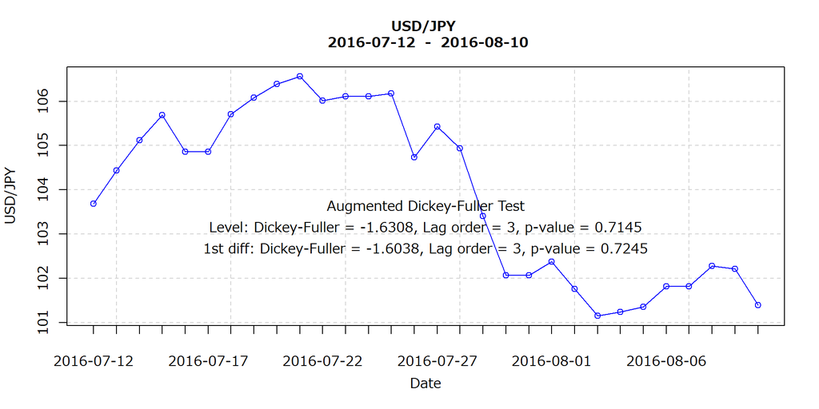

ARFIMAモデルでフィットさせた後の残差の正規性検定

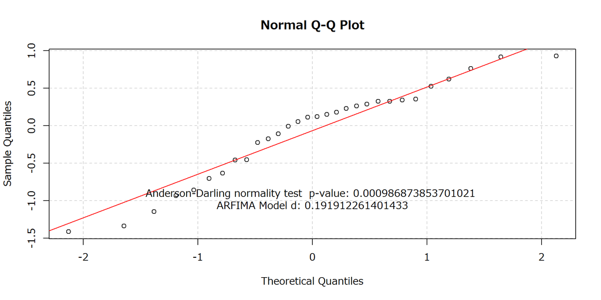

ARFIMAによる予測と為替レートの検証

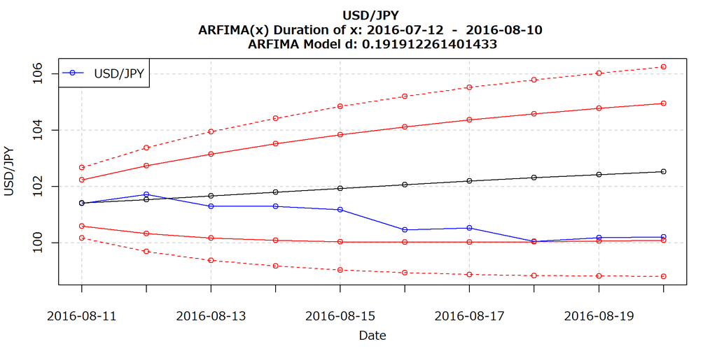

### Pattern 2 : 2016-05-13 - 2016-08-10 の為替レートによる予測検証

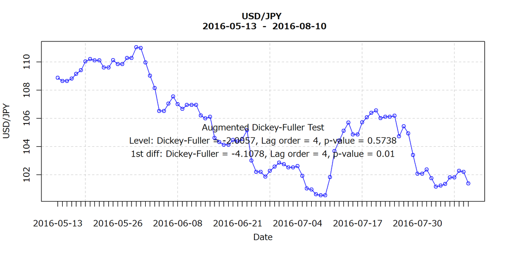

ARFIMAモデルでフィットさせた後の残差の正規性検定

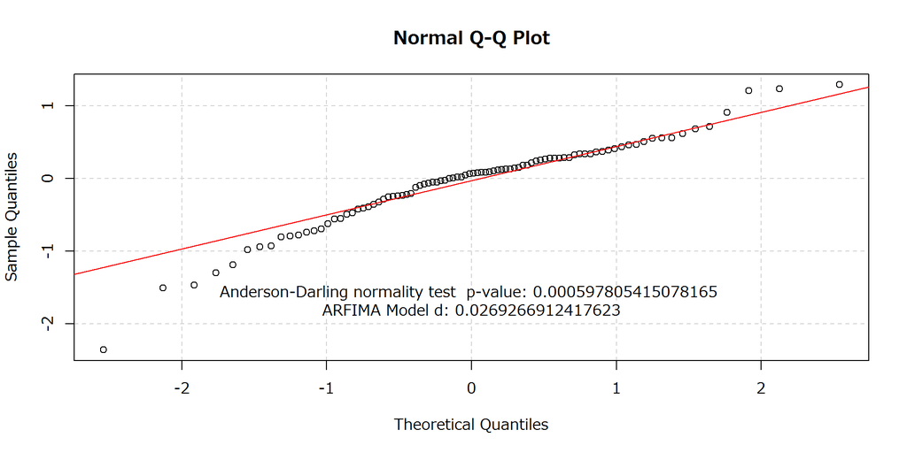

ARFIMAによる予測と為替レートの検証

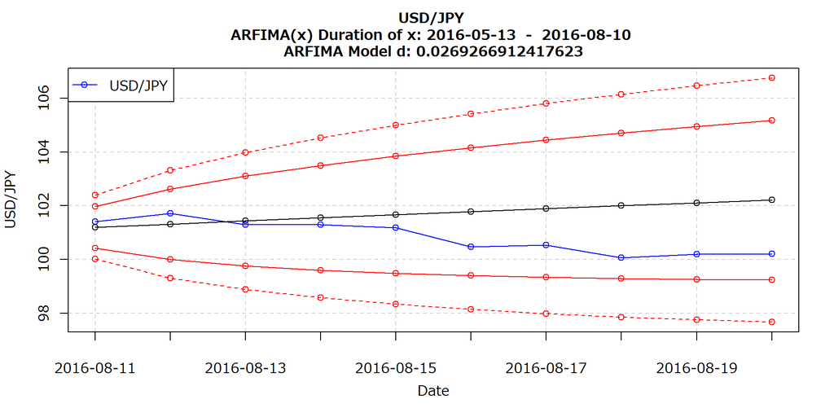

### Pattern 3 : 2016-02-13 - 2016-08-10 の為替レートによる予測検証

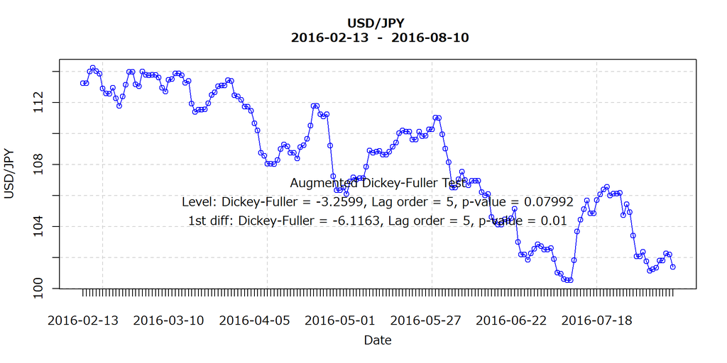

ARFIMAモデルでフィットさせた後の残差の正規性検定

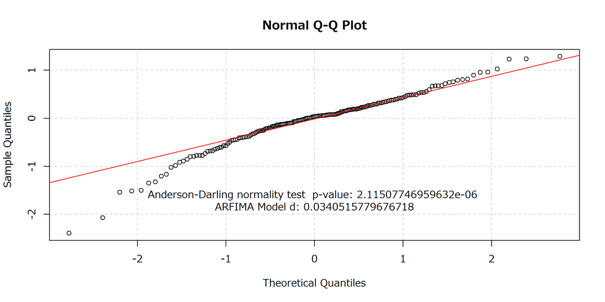

ARFIMAによる予測と為替レートの検証

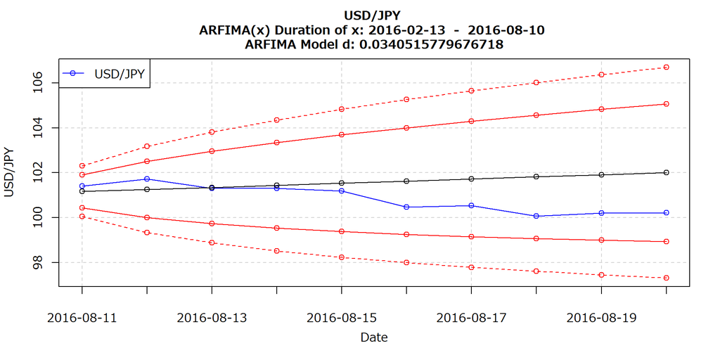

### Pattern 4 : 2015-08-17 - 2016-08-10 の為替レートによる予測検証

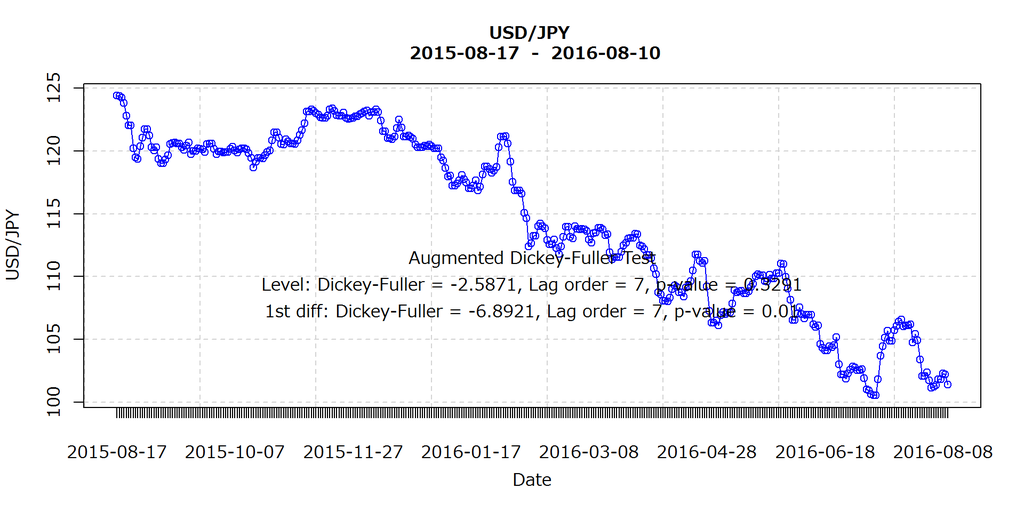

ARFIMAモデルでフィットさせた後の残差の正規性検定

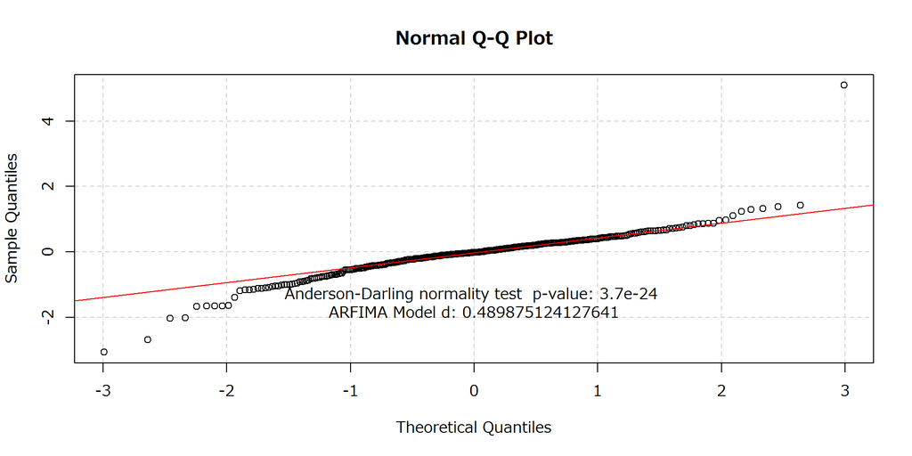

ARFIMAによる予測と為替レートの検証

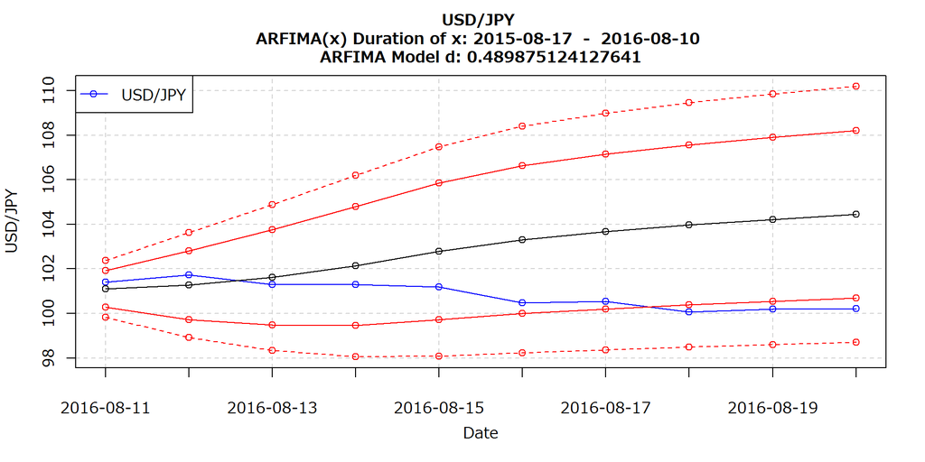

### Pattern 5 : 2014-08-22 - 2016-08-10 の為替レートによる予測検証

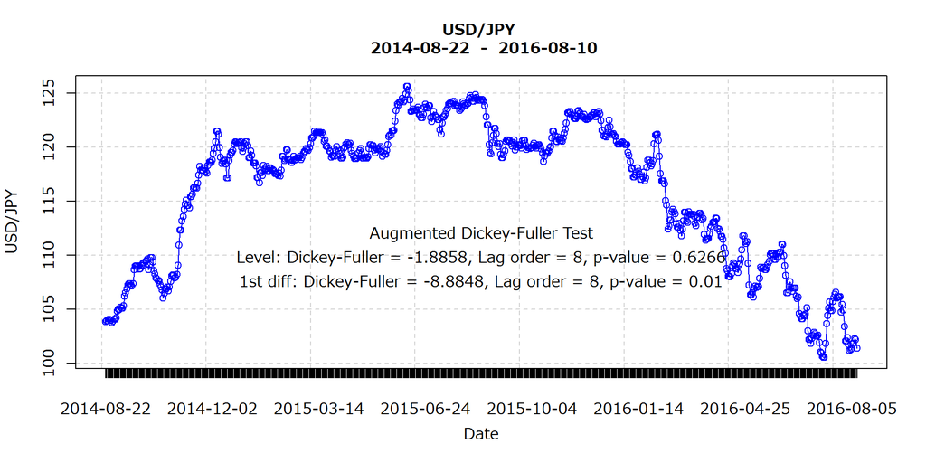

ARFIMAモデルでフィットさせた後の残差の正規性検定

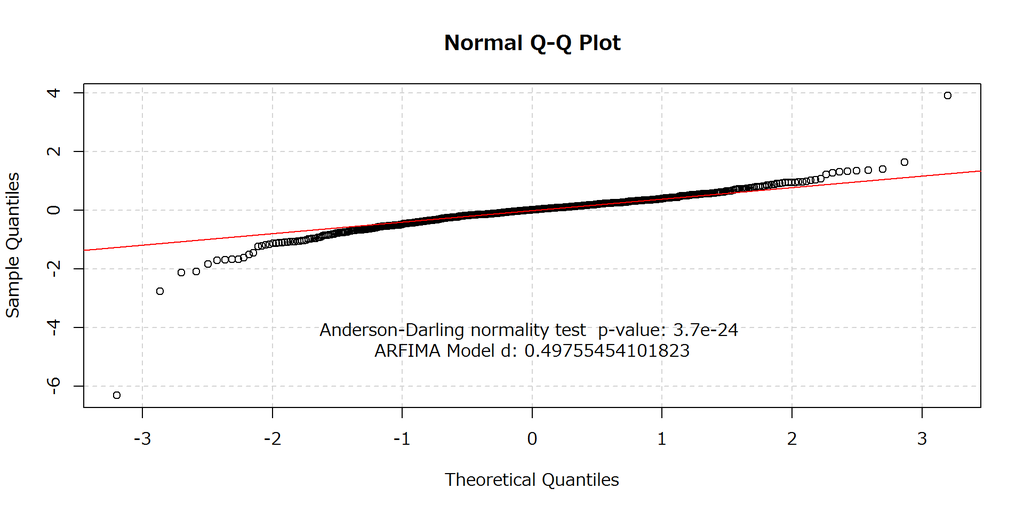

ARFIMAによる予測と為替レートの検証

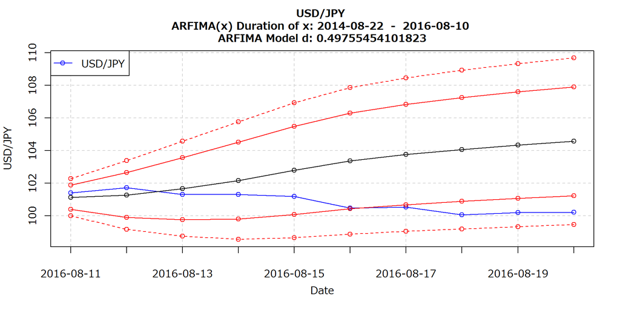

### Pattern 1 : 2016-07-22 - 2016-08-20 の為替レートによる予測

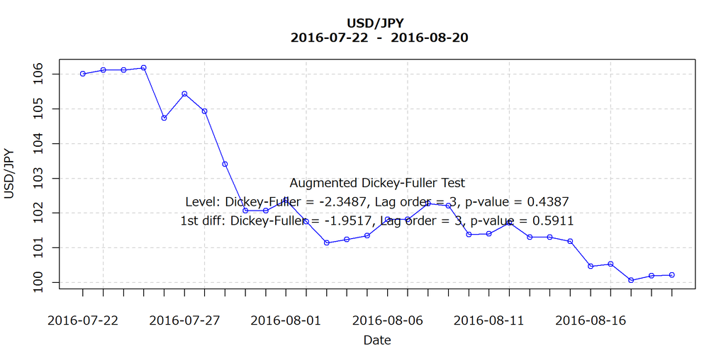

ARFIMAモデルでフィットさせた後の残差の正規性検定

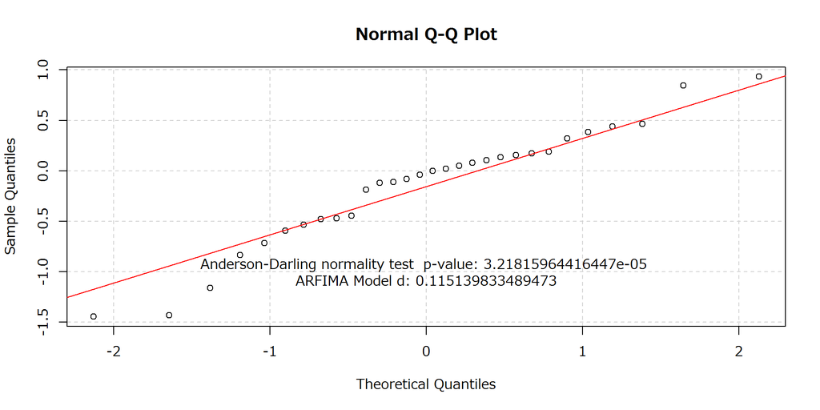

ARFIMAによる予測

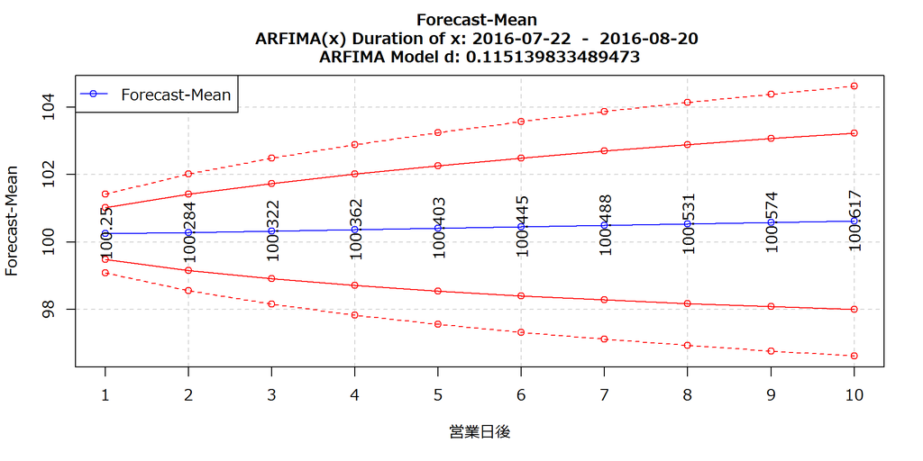

### Pattern 2 : 2016-05-23 - 2016-08-20 の為替レートによる予測

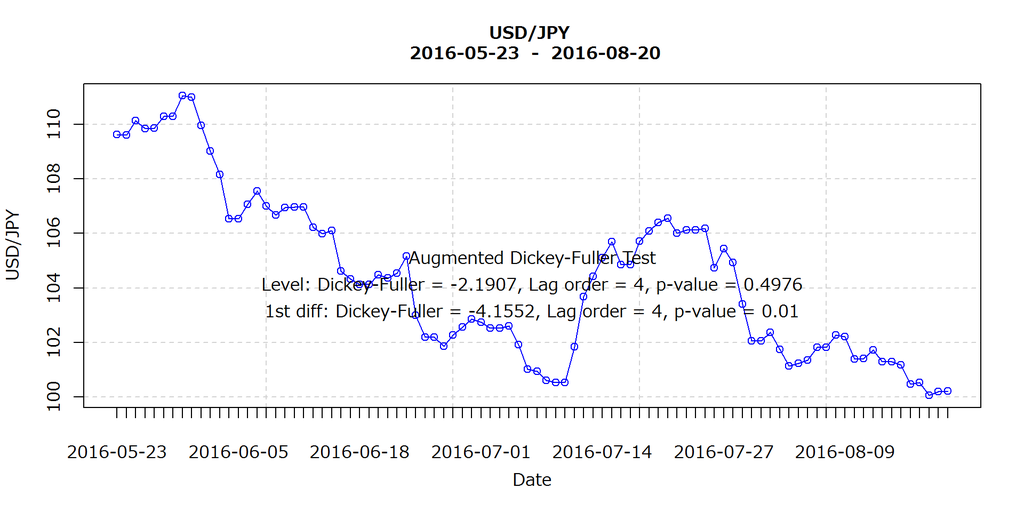

ARFIMAモデルでフィットさせた後の残差の正規性検定

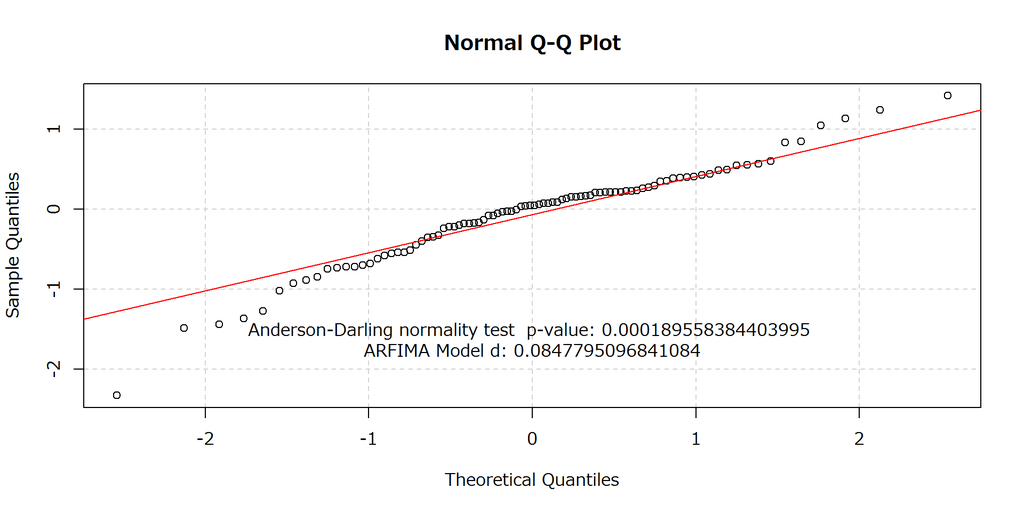

ARFIMAによる予測

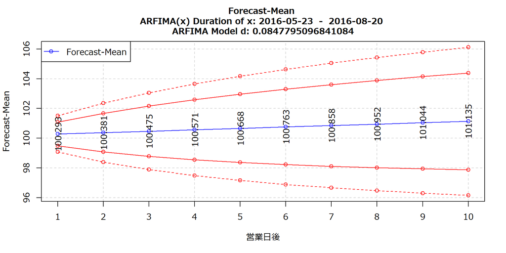

### Pattern 3 : 2016-02-23 - 2016-08-20 の為替レートによる予測

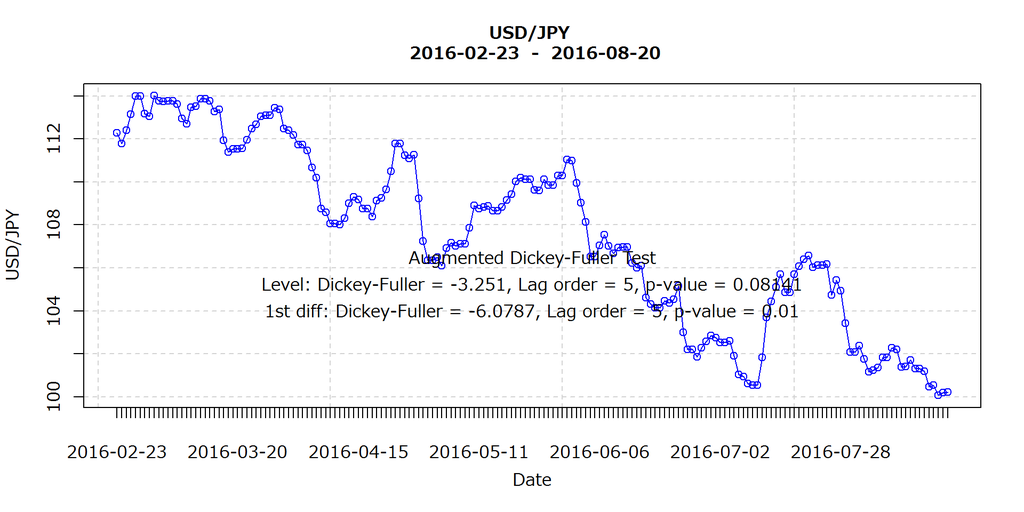

ARFIMAモデルでフィットさせた後の残差の正規性検定

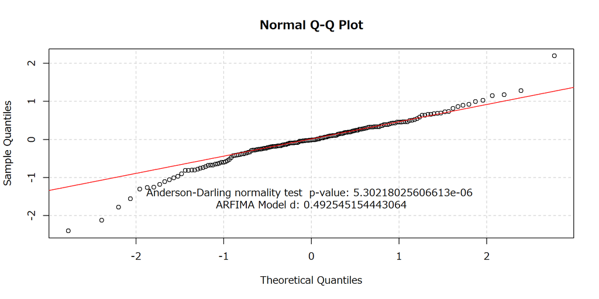

ARFIMAによる予測

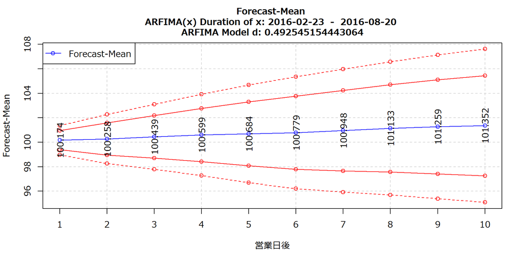

### Pattern 4 : 2015-08-27 - 2016-08-20 の為替レートによる予測

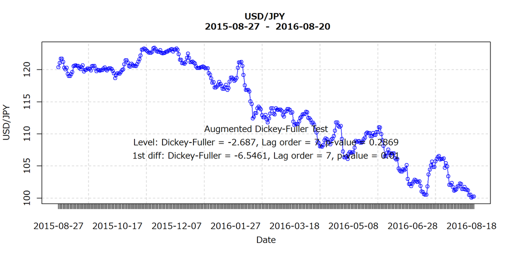

ARFIMAモデルでフィットさせた後の残差の正規性検定

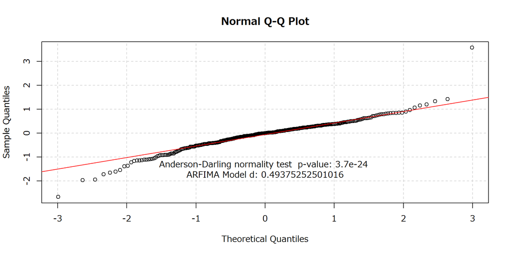

ARFIMAによる予測

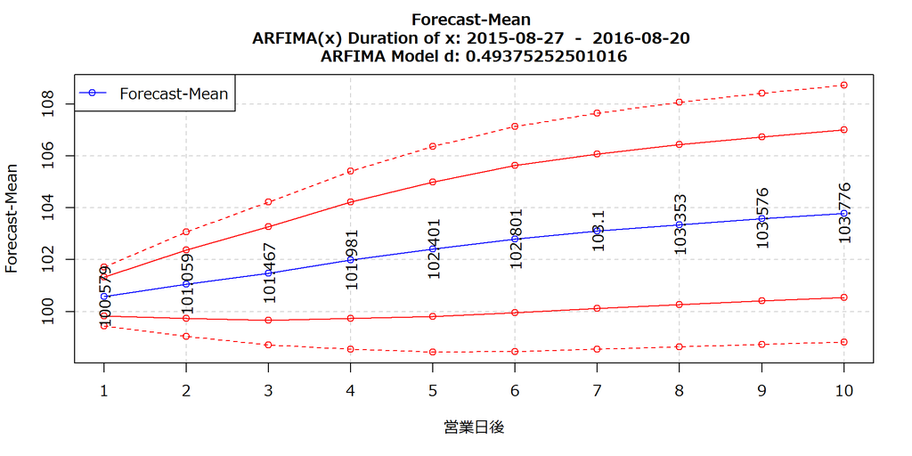

### Pattern 5 : 2014-09-01 - 2016-08-20 の為替レートによる予測

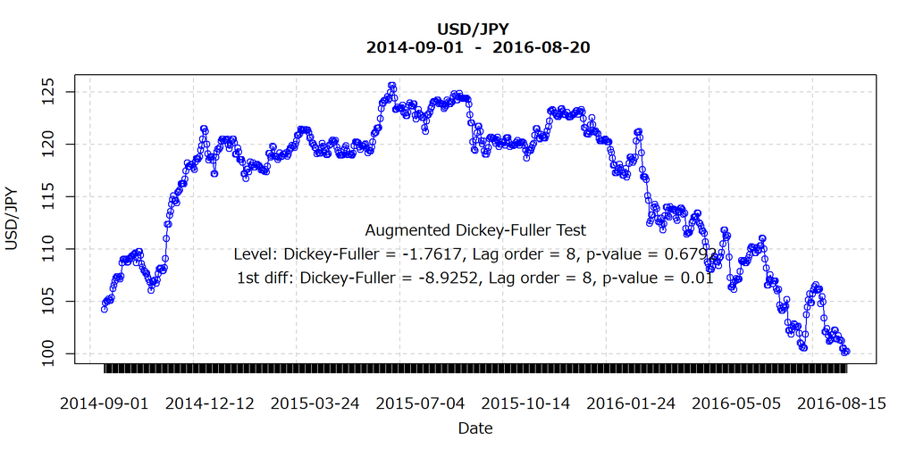

ARFIMAモデルでフィットさせた後の残差の正規性検定

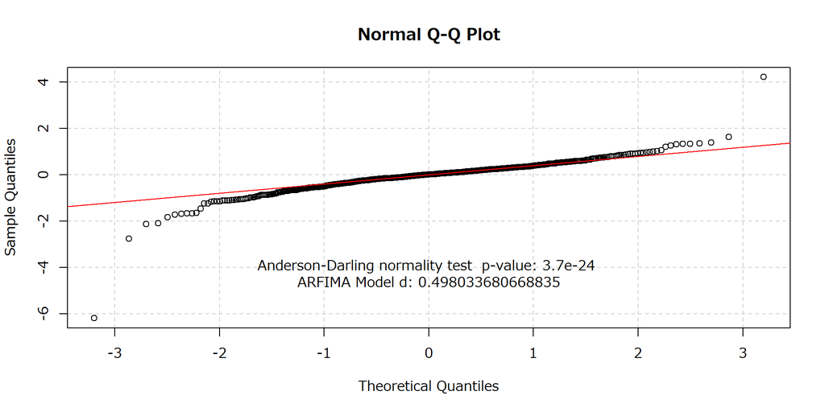

ARFIMAによる予測

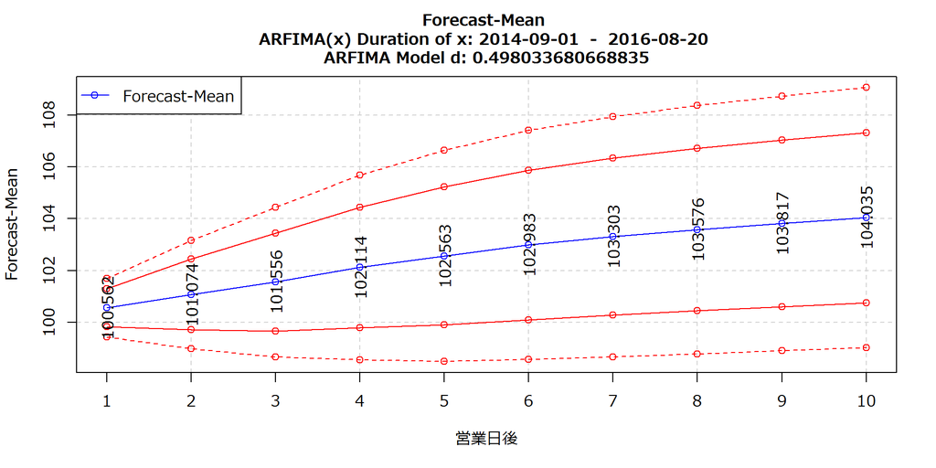